# MQ101 — Aula 05: Gráficos e Visualização de Dados

Teoria + Prática (R + ggplot2) — sequência contínua com demonstrações

Prof. Ricardo Ceneviva

08 outubro 2025

# 1 1. Objetivos e organização da aula

**Objetivos gerais** - Compreender o papel da visualização na análise e comunicação de dados. - Aplicar princípios de design e percepção visual para gráficos claros. - Dominar a *Grammar of Graphics* implementada em **ggplot2**. - Produzir visualizações reprodutíveis com código aberto (RMarkdown).

**Estrutura** - Sequência contínua: **conceito** → **demonstração**. - Uma apresentação HTML com código, saída e gráficos no mesmo artefato.

> Referência principal: Healy, K. (2024). *Data Visualization: A Practical Introduction*. Princeton University Press. Disponível em https://socviz.co/

# 2 2. Preparação do ambiente

## 2.1 2.1 Pacotes e dados

```r
required <- c("tidyverse", "gapminder", "viridis", "viridisLite", "scales")
to_install <- required[!sapply(required, requireNamespace, quietly = TRUE)]
if (length(to_install)) install.packages(to_install, repos = "https://cloud.r-project.org")
invisible(lapply(required, library, character.only = TRUE))

gm <- gapminder::gapminder
dplyr::glimpse(gm)
```

```
## Rows: 1,704
## Columns: 6
## $ country   <fct> "Afghanistan", "Afghanistan", "Afghanistan", "Afghanistan", …
## $ continent <fct> Asia, Asia, Asia, Asia, Asia, Asia, Asia, Asia, Asia, Asia, …
## $ year      <int> 1952, 1957, 1962, 1967, 1972, 1977, 1982, 1987, 1992, 1997, …
## $ lifeExp   <dbl> 28.801, 30.332, 31.997, 34.020, 36.088, 38.438, 39.854, 40.8…
## $ pop       <int> 8425333, 9240934, 10267083, 11537966, 13079460, 14880372, 12…
## $ gdpPercap <dbl> 779.4453, 820.8530, 853.1007, 836.1971, 739.9811, 786.1134, …
```

**Notas** - Usaremos `gapminder` para exemplos reprodutíveis e leves. - Variáveis principais: `year`, `country`, `continent`, `lifeExp`, `pop`, `gdpPercap`.

# 3 3. Por que visualizar? (conceito → demonstração)

## 3.1 3.1 Conceito

- Visualizações ajudam a **explorar**, **explicar** e **comunicar**.
- Bons gráficos reduzem carga cognitiva e evitam ambiguidade.
- Em políticas públicas, transparência e precisão são essenciais.

## 3.2 3.2 Demonstração: tabela vs gráfico simples

```r
df_bar <- gm |>
  dplyr::filter(year == 2007) |>
  dplyr::group_by(continent) |>
  dplyr::summarise(pop_bilhoes = sum(pop)/1e9, .groups = "drop") |>
  dplyr::arrange(desc(pop_bilhoes))

df_bar
```

| continent | pop_bilhoes |
| --- | --- |
| Asia | 3.81195383 |
| Africa | 0.92953969 |
| Americas | 0.89887118 |
| Europe | 0.58609853 |
| Oceania | 0.02454995 |

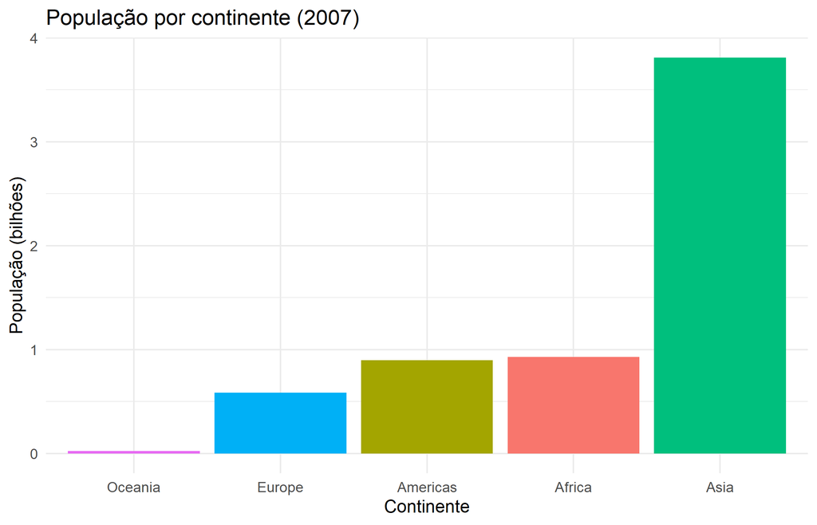

```r
ggplot(df_bar, aes(x = reorder(continent, pop_bilhoes), y = pop_bilhoes, fill = continent)) +
  geom_col(show.legend = FALSE) +
  labs(title = "População por continente (2007)",
       x = "Continente", y = "População (bilhões)") +
  theme_minimal()
```

# 4 4. Princípios de design (conceito → demonstração)

## 4.1 4.1 Conceito

- **Clareza e proporção**: escalas coerentes; evitar distorções.
- **Simplicidade**: remover ornamentos (3D, sombras desnecessárias).
- **Hierarquia visual**: títulos e rótulos informativos.
- **Acessibilidade**: contraste; paletas compatíveis com daltonismo.

## 4.2 4.2 Demonstração: pizza (não recomendado) vs barras (recomendado)

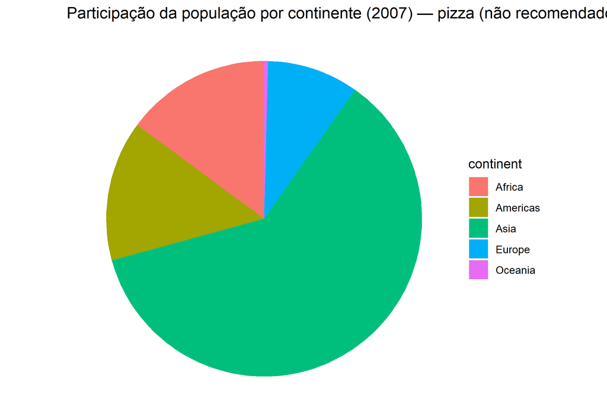

```r
p_pizza <- ggplot(df_bar, aes(x = "", y = pop_bilhoes, fill = continent)) +
  geom_col(width = 1) +
  coord_polar(theta = "y") +
  theme_void() +
  labs(title = "Participação da população por continente (2007) — pizza (não recomendado)")

p_barras <- ggplot(df_bar, aes(x = reorder(continent, pop_bilhoes), y = pop_bilhoes, fill = continent)) +
  geom_col(show.legend = FALSE) +
  labs(title = "População por continente (2007) — barras (recomendado)",
       x = "Continente", y = "População (bilhões)") +
  theme_minimal()

p_pizza
```

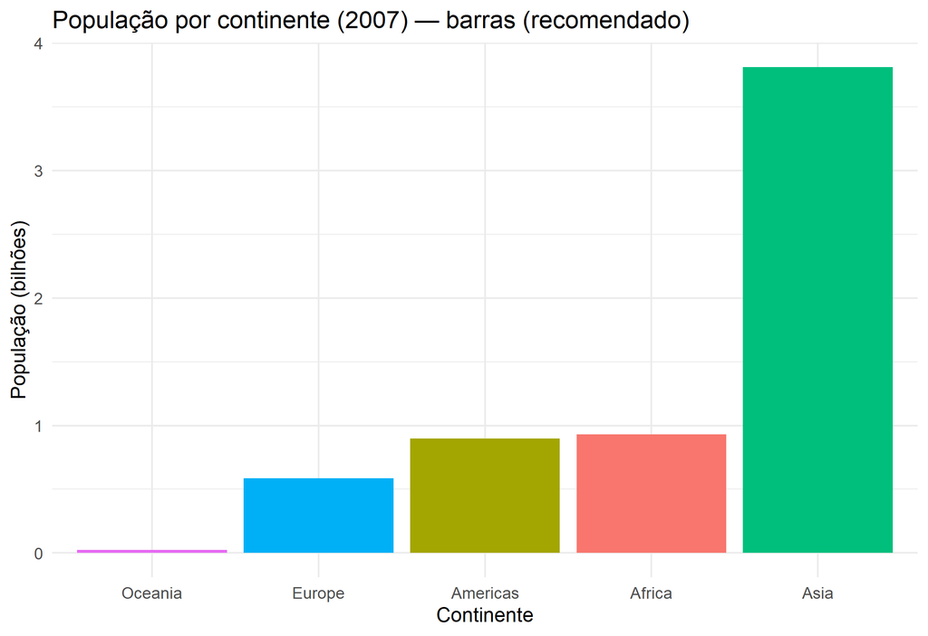

```r
p_barras
```

# 5 5. Grammar of Graphics (conceito → demonstração)

## 5.1 5.1 Conceito

- Componentes: **dados** • **estética (`aes`)** • **geometria (`geom`)** • **escala** • **facetas** • **tema**.
- Ideia central: mapear variáveis a propriedades visuais de forma declarativa.

## 5.2 5.2 Demonstração: mapeamentos estéticos e escalas

```r
gm2007 <- gm |> dplyr::filter(year == 2007)

# Exibir parte da base de dados para comparação (tabela vs gráfico)

gm2007 |>
  dplyr::select(country, continent, gdpPercap, lifeExp, pop) |>
  dplyr::arrange(desc(gdpPercap)) |>
  head(10) |>
  knitr::kable(
    caption = "Tabela 1 — Renda per capita e expectativa de vida (2007, 10 maiores PIBs per capita)",
    col.names = c("País", "Continente", "PIB per capita (US$)", "Expectativa de vida (anos)", "População"),
    format.args = list(big.mark = ".", decimal.mark = ",", digits = 10),
    align = "lccrr"
  )
```

Tabela 1 — Renda per capita e expectativa de vida (2007, 10 maiores PIBs per capita)

| País | Continente | PIB per capita (US$) | Expectativa de vida (anos) | População |
| --- | --- | --- | --- | --- |
| Norway | Europe | 49.357,19017 | 80,196 | 4.627.926 |
| Kuwait | Asia | 47.306,98978 | 77,588 | 2.505.559 |
| Singapore | Asia | 47.143,17964 | 79,972 | 4.553.009 |
| United States | Americas | 42.951,65309 | 78,242 | 301.139.947 |
| Ireland | Europe | 40.675,99635 | 78,885 | 4.109.086 |
| Hong Kong, China | Asia | 39.724,97867 | 82,208 | 6.980.412 |
| Switzerland | Europe | 37.506,41907 | 81,701 | 7.554.661 |
| Netherlands | Europe | 36.797,93332 | 79,762 | 16.570.613 |
| Canada | Americas | 36.319,23501 | 80,653 | 33.390.141 |
| Iceland | Europe | 36.180,78919 | 81,757 | 301.931 |

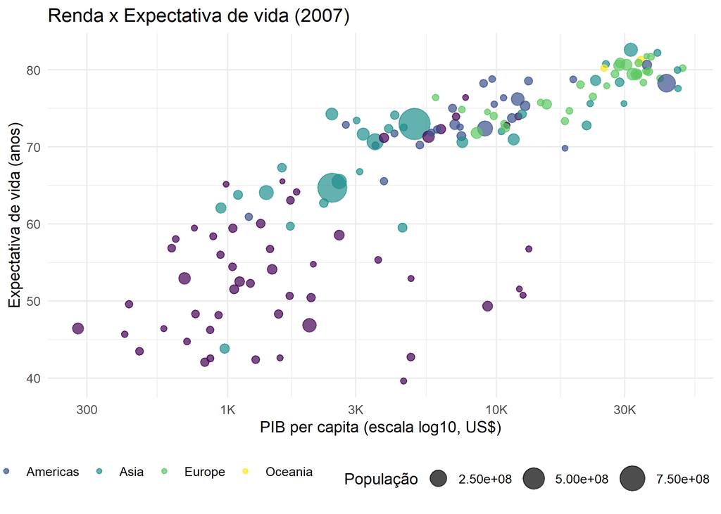

```r
ggplot(gm2007, aes(x = gdpPercap, y = lifeExp)) +
  geom_point(aes(size = pop, color = continent), alpha = 0.7) +
  scale_x_log10(labels = scales::label_number(scale_cut = scales::cut_short_scale())) +
  scale_size_continuous(name = "População", range = c(1.5, 10)) +
  scale_color_viridis_d(name = "Continente") +
  labs(title = "Renda x Expectativa de vida (2007)",
       x = "PIB per capita (escala log10, US$)",
       y = "Expectativa de vida (anos)") +
  theme_minimal() +
  theme(legend.position = "bottom")
```

# 6 6. Tipos de gráficos essenciais (conceito → demonstração)

## 6.1 6.1 Distribuições univariadas: histograma e densidade

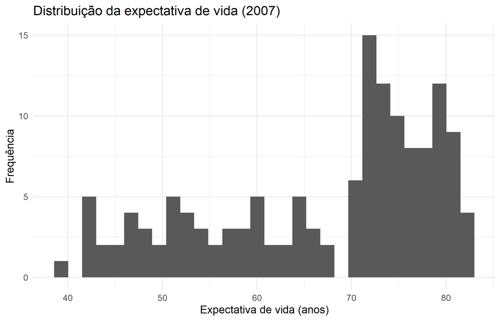

```r
p_hist <- ggplot(gm2007, aes(x = lifeExp)) +
  geom_histogram(bins = 30, boundary = 0, closed = "left") +
  labs(title = "Distribuição da expectativa de vida (2007)",
       x = "Expectativa de vida (anos)", y = "Frequência") +
  theme_minimal()

p_dens <- ggplot(gm2007, aes(x = lifeExp, fill = continent)) +
  geom_density(alpha = 0.4) +
  scale_fill_viridis_d(name = "Continente") +
  labs(title = "Densidade da expectativa de vida por continente (2007)",
       x = "Expectativa de vida (anos)", y = "Densidade") +
  theme_minimal()

p_hist
```

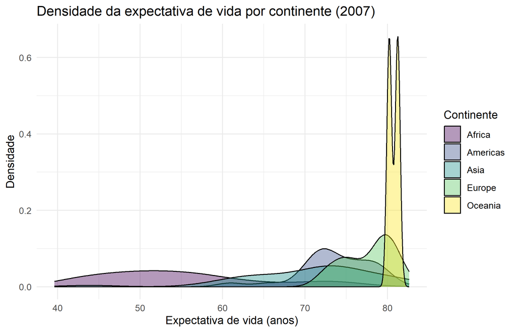

```r
p_dens
```

## 6.2 6.2 Relações bivariadas: dispersão e suavização

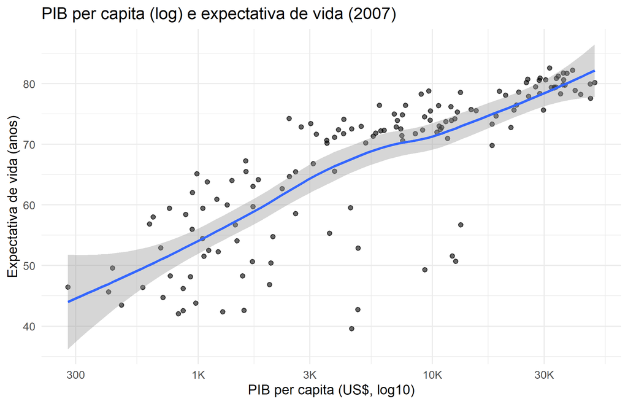

```r
ggplot(gm2007, aes(x = gdpPercap, y = lifeExp)) +
  geom_point(alpha = 0.6) +
  geom_smooth(method = "loess", se = TRUE) +
  scale_x_log10(labels = scales::label_number(scale_cut = scales::cut_short_scale())) +
  labs(title = "PIB per capita (log) e expectativa de vida (2007)",
       x = "PIB per capita (US$, log10)", y = "Expectativa de vida (anos)") +
  theme_minimal()
```

## 6.3 6.3 Comparação de distribuições: boxplot

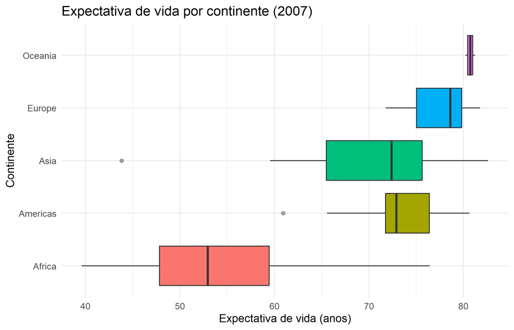

```r
ggplot(gm2007, aes(x = continent, y = lifeExp, fill = continent)) +
  geom_boxplot(show.legend = FALSE, outlier.alpha = 0.4) +
  coord_flip() +
  labs(title = "Expectativa de vida por continente (2007)",
       x = "Continente", y = "Expectativa de vida (anos)") +
  theme_minimal()
```

## 6.4 6.4 Séries temporais: linhas e pontos

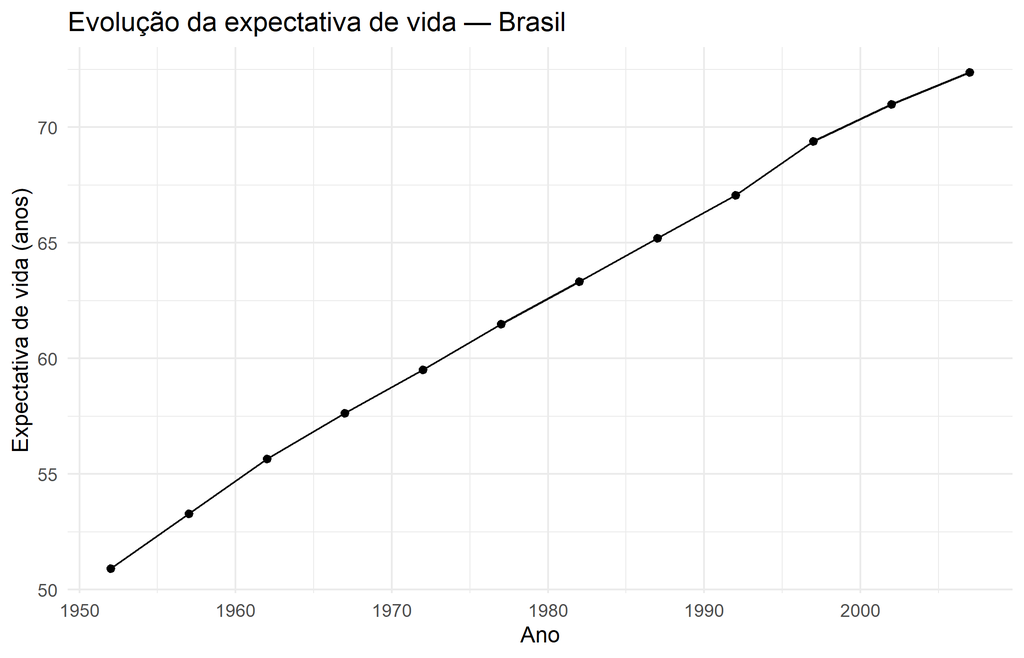

```r
gm_br <- gm |> dplyr::filter(country == "Brazil")

ggplot(gm_br, aes(x = year, y = lifeExp)) +
  geom_line() +
  geom_point() +
  labs(title = "Evolução da expectativa de vida — Brasil",
       x = "Ano", y = "Expectativa de vida (anos)") +
  theme_minimal()
```

## 6.5 6.5 Comparações por facetas

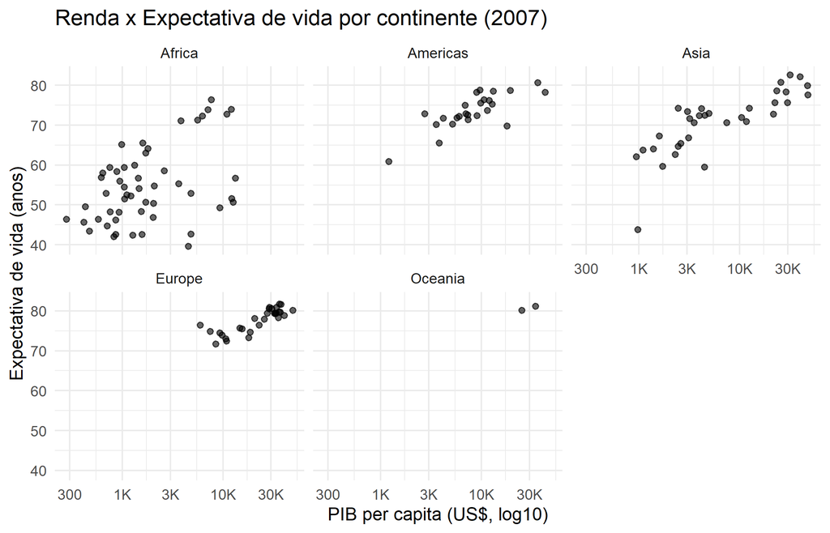

```r
ggplot(gm2007, aes(x = gdpPercap, y = lifeExp)) +
  geom_point(alpha = 0.6) +
  scale_x_log10(labels = scales::label_number(scale_cut = scales::cut_short_scale())) +
  facet_wrap(~ continent) +
  labs(title = "Renda x Expectativa de vida por continente (2007)",
       x = "PIB per capita (US$, log10)", y = "Expectativa de vida (anos)") +
  theme_minimal()
```

## 6.6 (a) Comparações por facetas com regressão linear (lm)

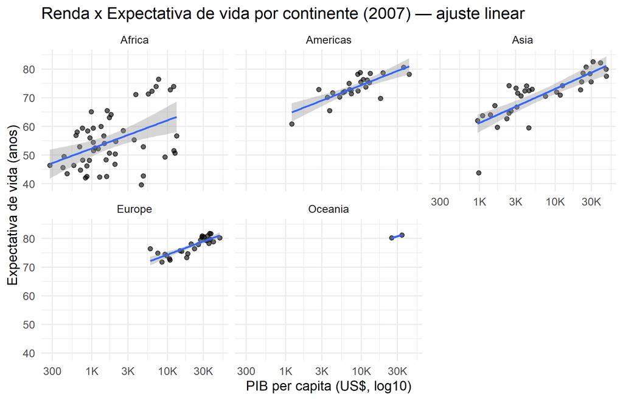

```r
ggplot(gm2007, aes(x = gdpPercap, y = lifeExp)) +
  geom_point(alpha = 0.6) +
  geom_smooth(method = "lm", se = TRUE, linewidth = 0.8) +
  scale_x_log10(labels = scales::label_number(scale_cut = scales::cut_short_scale())) +
  facet_wrap(~ continent) +
  labs(
    title = "Renda x Expectativa de vida por continente (2007) — ajuste linear",
    x = "PIB per capita (US$, log10)", y = "Expectativa de vida (anos)"
  ) +
  theme_minimal()
```

## 6.7 (b) Comparações por facetas com com suavização LOESS

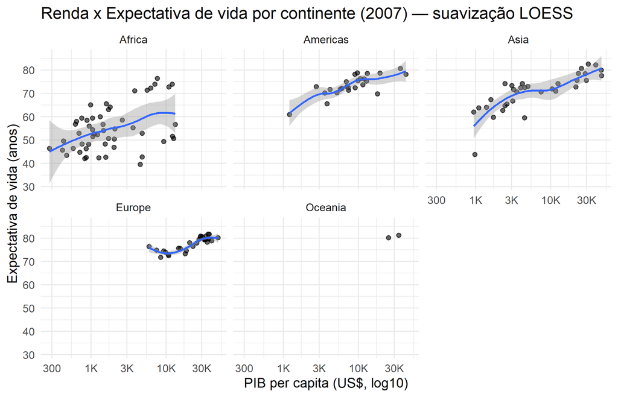

```r
ggplot(gm2007, aes(x = gdpPercap, y = lifeExp)) +
  geom_point(alpha = 0.6) +
  geom_smooth(method = "loess", se = TRUE, linewidth = 0.8, span = 0.8) +
  scale_x_log10(labels = scales::label_number(scale_cut = scales::cut_short_scale())) +
  facet_wrap(~ continent) +
  labs(
    title = "Renda x Expectativa de vida por continente (2007) — suavização LOESS",
    x = "PIB per capita (US$, log10)", y = "Expectativa de vida (anos)"
  ) +
  theme_minimal()
```

# 7 7. Rótulos, temas e anotações (conceito → demonstração)

## 7.1 7.1 Conceito

- Títulos informativos, eixos autoexplicativos, legendas claras.
- Temas consistentes evitam ruído visual.
- Anotações ajudam a destacar padrões.

## 7.2 7.2 Demonstração

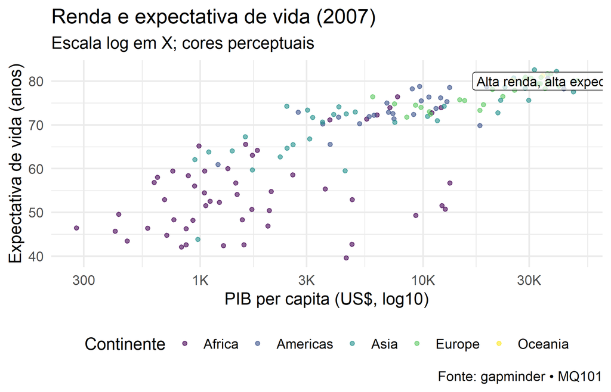

```r
p <- ggplot(gm2007, aes(gdpPercap, lifeExp)) +
  geom_point(alpha = 0.6, aes(color = continent)) +
  scale_x_log10(labels = scales::label_number(scale_cut = scales::cut_short_scale())) +
  scale_color_viridis_d(name = "Continente") +
  labs(
    title = "Renda e expectativa de vida (2007)",
    subtitle = "Escala log em X; cores perceptuais",
    caption = "Fonte: gapminder • MQ101",
    x = "PIB per capita (US$, log10)", y = "Expectativa de vida (anos)"
  ) +
  theme_minimal(base_size = 14) +
  theme(legend.position = "bottom")

p + annotate("label", x = 40000, y = 80, label = "Alta renda, alta expectativa", alpha = 0.7)
```

# 8 8. Escalas e transformações (conceito → demonstração)

## 8.1 8.1 Conceito

- Transformações (ex.: `log10`) reduzem assimetria e melhoram leitura.
- Escalas controlam rótulos, limites e quebras.

## 8.2 8.2 Demonstração

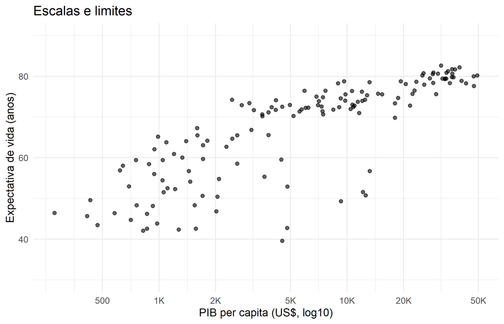

```r
ggplot(gm2007, aes(gdpPercap, lifeExp)) +
  geom_point(alpha = 0.6) +
  scale_x_log10(
    breaks = c(500, 1000, 2000, 5000, 10000, 20000, 50000),
    labels = scales::label_number(scale_cut = scales::cut_short_scale())
  ) +
  coord_cartesian(ylim = c(30, 90)) +
  labs(title = "Escalas e limites", x = "PIB per capita (US$, log10)", y = "Expectativa de vida (anos)") +
  theme_minimal()
```